# Lesson 9: Aggregate Demand and Aggregate Supply

# Part One: Aggregate Demand (AD) Curve

The aggregate demand curve demonstrates the negative relationship between inflation ($\pi$) and overall output (Y) when the goods market is in equilibrium.

We already know about the IS (Investment Savings) and the MP (Monetary Policy) cuves:
$$Y(r)$$
$$r(\pi)$$

We can get the AD curve through the composition of functions:

$$Y(r(\pi)) = Y(\pi)$$

Recall the IS Curve:
$$Y = \frac{1}{(1 - MPC)}(\overline{C}+ \overline{I}+ \overline{G} + \overline{NX} -MPC\overline{T}- d\overline{f}) - r(\frac{c+d+x}{1-MPC})$$
Let us denotes the variable A as:
$$A = \frac{1}{(1 - MPC)}(\overline{C}+ \overline{I}+ \overline{G} + \overline{NX} -MPC\overline{T}- d\overline{f})$$
And we have our MP curve:
$$r = \overline{r} + \lambda\pi$$
We get the composition (AD Curve):
$$Y = A -(\frac{c+d+x}{1-MPC})r(\pi)$$
$$Y = A - (\frac{c+d+x}{1-MPC})(\overline{r} + \lambda\pi)$$
$$Y = A - \overline{r}(\frac{c+d+x}{1-MPC}) - \lambda\pi(\frac{c+d+x}{1-MPC})$$

From this equation you can see everything but $\lambda$ and $\pi$ helps to shift the function. Note that when you look at shifts for each the IS curve and the AD curve move horizontally (left and right), while the MP curve moves vertically (up and down) based off the response variable of their function.

For example if we have the following IS and MP Curves:
$$Y = 12 - r$$
$$r = 1 + 0.5\pi$$

Then we get the AD Curve:
$$Y = 12 - (1 + 0.5\pi) = 11 - 0.5\pi$$

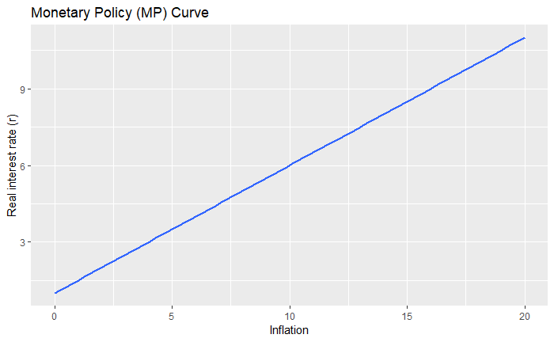

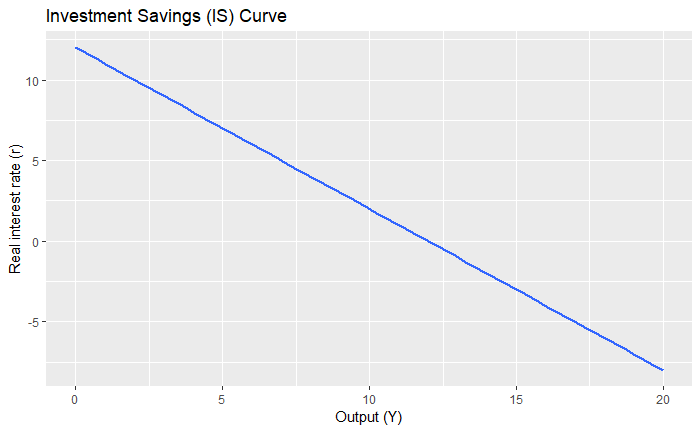

[figure not shown]

# Part Two: The Phillips Curve

## Friedman-Phelps Phillips Curve

The aggregate demand curve shows the relationship of inflation and ouput, but where does the inflation rate come from? The Phillips Curve shows the negative relationship between unemployment and inflation.

We know that when unemployment is low, the market is tighter. Tighter markets lead to higher wages. Higher wages lead to higher prices, which means an increase inflation. This was taken as a **fact** in 1960.

In 1967/68 Friedman and Phelps argued that in the long run prices adjust and we arrive at the natural rate of unemployment. From this we get the Friedman-Phelps Phillips curve:
$$\pi = \pi^e - w(u - u_n)$$

where u - u<sub>n</sub> is the unemployment gap. This is known as the “Expectations-Augmented Phillips Curve”.

## 3 Conclusions

1. No long run trade-offs between unemployment and inflation, because prices adjust
2. There is a short run trade-off
3. There are two types of Phillips Curves (SRPC, LRPC)

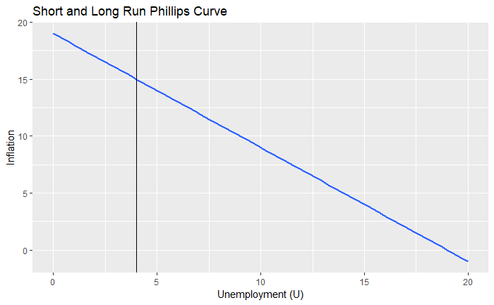

## The Modern Phillips Curve

In 1973 and 1979 the United States economy encountered “oil shocks.”
$$\pi = \pi^e - \omega(u-u_n) + \rho$$

### Phillips Curve with Adaptive Expectations

“What has the pattern been? I am going to predict according to that pattern.”

$$\pi^e = \pi_{-1}$$
$$\pi = \pi_{-1}-\omega(u-u_n)+\rho$$

Two advantages:

1. Provides reason for sticky prices and sticky wages
   - $\pi$ may not fully adjust because people only look backwards
2. We can look at $\Delta\pi = \pi - \pi_{-1}$

$$\pi - \pi_{-1} = -q(u-u_n) + \rho$$

Assume $\rho = 0$

Therefor $\Delta\pi = 0$ if and only if $u = u_n$, so we call u<sub>n</sub> NAIRU. This is Non-Accelerating Inflation Rate of Unemployment.

# Part Three: Aggregate Supply Curves

Aggregate Supply Curves are the relationship between the output (Y) that firms are willing to supply and inflation (price level $\pi$).

## Long Run Aggregate Supply Curve (LRAS)

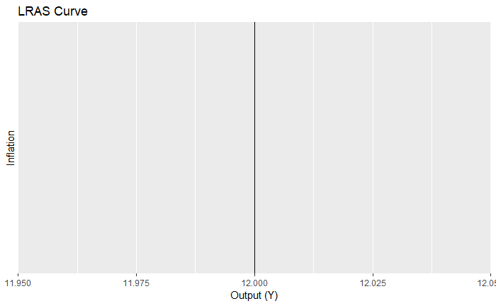

“Input prices are going to change to what output prices are changing”

### Shifts

1. Increase in Productivity shifts LRAS right ($\Delta A$)
2. Increase in Capial, Labor, etc… shifts LRAS right ($\Delta inputs$)
3. Institutions (policy or such to create incentive for economic growth)
   - Property Rights, Rule of Law, education system, healthcare system…

## Short Run Aggregate Supply Curve (SRAS)

Take the Phillips curve and replace the unemployment gap ($u-u_n$) with the output gap ($Y-Y^p$).

**Okun’s Law:**

- For each percentage point Y is above Y<sup>p</sup>
- u is 1/2 percentage point below the natural rate u<sub>n</sub>
- $(u - u_n) = -0.5(Y = Y^p)$

SRAS equation (plug in Okun’s law to PC):
$$\pi = \pi_{-1}+0.5\omega(Y - Y^p) + \rho$$
$$\pi = \pi_{-1}+ \gamma(Y - Y^p) + \rho$$

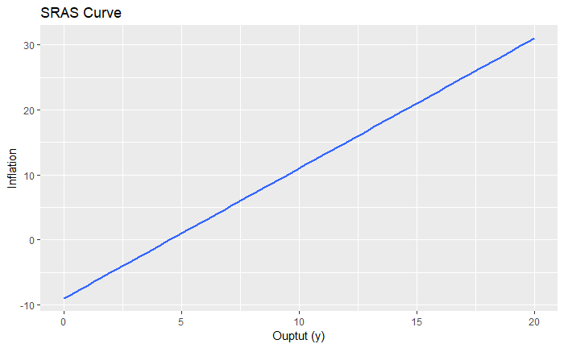

### Shifts

1. Increase in expected inflation $\Delta\pi^e = \Delta\pi_{-1}$
2. Increase in price shock shifts curve up (left) ($\Delta\rho$)
3. The output gap ($\Delta(Y - Y^p)$)
   - If $Y\ne Y^p$ the we have $\Delta\pi$, so $\pi_{-1}$ changes

# Summary

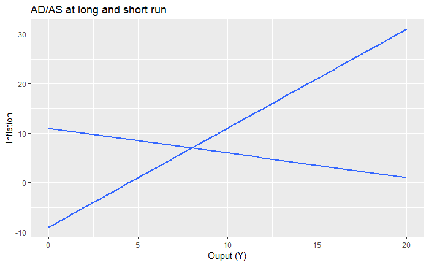

General Equilibrium when AD = AS (this is SRAS) you can solve for $\pi$:

1. AD: $y(\pi)$
2. AS: $\pi(y)$

Long Run General Equilirbium LRAS = AS = AD

- $u - u_n$
- $y = y^p$
- $\pi = \pi^e$

Q: If we are in a short run general equilibrium (SR-GE), how does the economy get to the long run general equilibrium (LR-GE)?

1. Self-Correcting Mechanism (Lesson 9)
2. Policy Action (Lesson 10)

## Expansion (Y > Y<sup>p</sup>)

We see a positive output gap (producing more than we would in LRAS). This means the labor market must be tight, which means wages will increase. Higher wages lead to higher inflation, which makes one expect higher inflation, which shifts AS curve up. When AS shifts up it will move the equilibrium point toward the LRAS curve. This means it will self correct to the LR-GE.

## Recession (Y < Y<sup>p</sup>)

We see a negative output gap (producing less than we would in LRAS). This means we have “slack” in the labor market (workers willing to work). This creates a downward pressure on wages, which results in a disinflation. You would then expect a decrease in inflation, so AS would shift downward. This means it would self correct to LR-GE.